# Content

# How to Load Numpy Arrays from Text

```python
# This is your data in the text file

# Value1  Value2  Value3
# 0.2536  0.1008  0.3857
# 0.4839  0.4536  0.3561
# 0.1292  0.6875  0.5929
# 0.1781  0.3049  0.8928
# 0.6253  0.3486  0.8791
```

```python
# Import your data
# loadtxt
x, y, z = np.loadtxt('textfile.txt',
                    skiprows = 1,
                    unpack = True)
# unpack=TRUE
# the values in column Value1 will be put in x, and so on
# delimiter
# comma-delimited data
# specify the data type
# dtype

print(x)
print(y)
print(z)
```

```
[ 0.2536  0.4839  0.1292  0.1781  0.6253]
[ 0.1008  0.4536  0.6875  0.3049  0.3486]
[ 0.3857  0.3561  0.5929  0.8928  0.8791]
```

```python
# Your data in the text file

# Value1  Value2  Value3
# 0.4839  0.4536  0.3561
# 0.1292  0.6875  MISSING
# 0.1781  0.3049  0.8928
# MISSING 0.5801  0.2038
# 0.5993  0.4357  0.7410
```

```python
# genfromtxt
my_array2 = np.genfromtxt('textfile2.txt',
                      skip_header = 1,
                      filling_values = -999)
# filling_values
# converts character strings in numeric columns to nan,
# you can convert these values to other ones
# missing_values
# argument that allows you to specify what the missing values

print(my_array2)
```

```
[[  4.83900000e-01   4.53600000e-01   3.56100000e-01]
 [  1.29200000e-01   6.87500000e-01  -9.99000000e+02]
 [  1.78100000e-01   3.04900000e-01   8.92800000e-01]
 [ -9.99000000e+02   5.80100000e-01   2.03800000e-01]
 [  5.99300000e-01   4.35700000e-01   7.41000000e-01]]
```

# How to Save Numpy Arrays

```python
x = np.arange(0.0,5.0,1.0) # array of evenly-spaced values from 0 to 5 by 1

np.savetxt('test1.txt', x, delimiter=',') # to a text file
np.save('test2.npy', x) # to a binary file
np.savez('test3.npz', x) # to a uncompressed archive
np.savez_compressed('test4.npz', x) # compressed archive
```

# How to Inspect your Numpy Arrays

Almost all the attributes that an array can have.

```python
# Print the number of `my_array`'s dimensions
print(my_array.ndim)
```

```
2
```

```python
# Print the number of `my_array`'s elements
print(my_array.size)
```

```
8
```

```python
# Print information about `my_array`'s memory layout
print(my_array.flags)
```

```
  C_CONTIGUOUS : True
  F_CONTIGUOUS : False
  OWNDATA : True
  WRITEABLE : True
  ALIGNED : True
  UPDATEIFCOPY : False
```

```python
# Print the length of one array element in bytes
print(my_array.itemsize)
```

```
8
```

```python
# Print the total consumed bytes by `my_array`'s elements
print(my_array.nbytes)
```

```
64
```

```python
# Print the length of `my_array`
print(len(my_array))
```

```
2
```

```python
# Change the data type of `my_array`
my_array.astype(float)
```

```
array([[ 1.,  2.,  3.,  4.],
       [ 5.,  6.,  7.,  8.]])
```

# How Numpy Broadcasting Works

Work with arrays of different shapes when you’re performing arithmetic operations.

```python
# Initialize `x`
x = np.ones((3,4))

# Check shape of `x`
print(x.shape)
```

```
(3, 4)
```

```python
# Initialize `y`
y = np.random.random((3,4))

# Check shape of `y`
print(y.shape)
```

```
(3, 4)
```

```python
print(x)
print(y)
```

```
[[ 1.  1.  1.  1.]
 [ 1.  1.  1.  1.]
 [ 1.  1.  1.  1.]]
[[ 0.9739925   0.65868552  0.78585408  0.72153181]
 [ 0.42015346  0.86823462  0.40408882  0.70265655]
 [ 0.83310588  0.70637705  0.77264593  0.98474457]]
```

```python
# Add `x` and `y`
x + y
```

```
array([[ 1.9739925 ,  1.65868552,  1.78585408,  1.72153181],
       [ 1.42015346,  1.86823462,  1.40408882,  1.70265655],
       [ 1.83310588,  1.70637705,  1.77264593,  1.98474457]])
```

```python
# Initialize `y`
y2 = np.arange(4)

# Check shape of `y`
print(y2.shape)
```

```
(4,)
```

```python
print(x)
print(y2)
```

```
[[ 1.  1.  1.  1.]
 [ 1.  1.  1.  1.]
 [ 1.  1.  1.  1.]]
[0 1 2 3]
```

```python
# Subtract `x` and `y`
x - y2
```

```
array([[ 1.,  0., -1., -2.],
       [ 1.,  0., -1., -2.],
       [ 1.,  0., -1., -2.]])
```

```python
# Initialize `x` and `y`
x2 = np.ones((3,4))
y3 = np.random.random((5,1,4))
```

```python
print(x2.shape)
print(y3.shape)
```

```
(3, 4)
(5, 1, 4)
```

```python
print(x2)
print(y3)
```

```
[[ 1.  1.  1.  1.]
 [ 1.  1.  1.  1.]
 [ 1.  1.  1.  1.]]
[[[ 0.0254518   0.44760918  0.21975297  0.60486321]]

 [[ 0.37762206  0.11207185  0.83155548  0.54374899]]

 [[ 0.61544874  0.09904125  0.63245271  0.53527454]]

 [[ 0.5328334   0.06408051  0.09909692  0.99252594]]

 [[ 0.30833275  0.80238428  0.90487682  0.29399638]]]
```

```python
# Add `x` and `y`
x2 + y3
```

```
array([[[ 1.0254518 ,  1.44760918,  1.21975297,  1.60486321],
        [ 1.0254518 ,  1.44760918,  1.21975297,  1.60486321],
        [ 1.0254518 ,  1.44760918,  1.21975297,  1.60486321]],

       [[ 1.37762206,  1.11207185,  1.83155548,  1.54374899],
        [ 1.37762206,  1.11207185,  1.83155548,  1.54374899],
        [ 1.37762206,  1.11207185,  1.83155548,  1.54374899]],

       [[ 1.61544874,  1.09904125,  1.63245271,  1.53527454],
        [ 1.61544874,  1.09904125,  1.63245271,  1.53527454],
        [ 1.61544874,  1.09904125,  1.63245271,  1.53527454]],

       [[ 1.5328334 ,  1.06408051,  1.09909692,  1.99252594],
        [ 1.5328334 ,  1.06408051,  1.09909692,  1.99252594],
        [ 1.5328334 ,  1.06408051,  1.09909692,  1.99252594]],

       [[ 1.30833275,  1.80238428,  1.90487682,  1.29399638],
        [ 1.30833275,  1.80238428,  1.90487682,  1.29399638],
        [ 1.30833275,  1.80238428,  1.90487682,  1.29399638]]])
```

But what if the dimensions are not compatible? What if they are not equal or if one of them is not equal to 1? You’ll have to fix this by manipulating your array.

# How Do Array Mathematics Work?

- `np.add(), np.subtract(), np.multiply(), np.divide() and np.remainder()`.

```python
x = np.array([[1, 2, 3], [3, 4, 5]])
y = np.array([6, 7, 8])

print(x)
print(y)
```

```
[[1 2 3]
 [3 4 5]]
[6 7 8]
```

```python
# Add `x` and `y`
np.add(x,y)
```

```
array([[ 7,  9, 11],
       [ 9, 11, 13]])
```

```python
# Subtract `x` and `y`
np.subtract(x,y)
```

```
array([[-5, -5, -5],
       [-3, -3, -3]])
```

```python
# Multiply `x` and `y`
np.multiply(x,y)
```

```
array([[ 6, 14, 24],
       [18, 28, 40]])
```

```python
# Divide `x` and `y`; x/y
np.divide(x,y)
```

```
array([[ 0.16666667,  0.28571429,  0.375     ],
       [ 0.5       ,  0.57142857,  0.625     ]])
```

```python
# Calculate the remainder of `x` and `y`
np.remainder(x,y)
```

```
array([[1, 2, 3],
       [3, 4, 5]])
```

- `np.exp(), np.sqrt(), np.log()`.
- `np.dot()`.
- `a.sum(), a.min(), a.max(axis=0), a.cumsum(axis=1), a.mean(), a.median(), a.corrcoef(), a.std(b)`.

```python
x = np.array([[1, 2, 3], [3, 4, 5]])
print(x)
```

```
[[1 2 3]
 [3 4 5]]
```

```python
x.sum()
```

```
18
```

```python
x.min()
```

```
1
```

```python
y = np.array([6, 7, 8])
print(y)
```

```
[6 7 8]
```

```python
y.max(axis=0)
```

```
8
```

```python
x.max(axis=1)
```

```
array([3, 5])
```

```python
y.cumsum(axis=0)
```

```
array([ 6, 13, 21])
```

```python
x.mean()
```

```
3.0
```

```python
np.std(x)
```

```
1.2909944487358056
```

- `==, <, >`.
- `np.array_equal()`
- `np.logical_or(), np.logical_not(), np.logical_and()`.

```python
a = np.array([True, True, False, False])
b = np.array([False, False, True, True])
```

```python
# `a` AND `b`
np.logical_and(a, b)
```

```
array([False, False, False, False], dtype=bool)
```

```python
# `a` OR `b`
np.logical_or(a, b)
```

```
array([ True,  True,  True,  True], dtype=bool)
```

```python
# `a` NOT `b`
np.logical_not(a,b)
```

```
array([False, False,  True,  True], dtype=bool)
```

# How to Subset, Slice, and Index Arrays

- `a[start:end]`, items start through the end (but the end is not included!).
- `a[start:]`, items start through the rest of the array.
- `a[:end]`, items from the beginning through the end (but the end is not included!).

```python
my_array = np.array([1,2,3,4])
print(my_array)
```

```
[1 2 3 4]
```

```python
# Select the element at the 1st index
print(my_array[1])
```

```
2
```

```python
print(my_2d_array)
```

```
[[1 2 3 4]
 [5 6 7 8]]
```

```python
# Select the element at row 1 column 2
print(my_2d_array[1][2])
```

```
7
```

```python
# Select the element at row 1 column 2
print(my_2d_array[1,2])
```

```
7
```

```python
print(my_3d_array)
```

```
[[[ 1  2  3  4]
  [ 5  6  7  8]]

 [[ 1  2  3  4]
  [ 9 10 11 12]]]
```

```python
# Select the element at row 1, column 2 and
print(my_3d_array[1,1,2])
```

```
11
```

```python
# Select items at index 0 and 1
print(my_array[0:2])
```

```
[1 2]
```

```python
# Select items at row 0 and 1, column 1
print(my_2d_array[0:2,1])
```

```
[2 6]
```

```python
# Select items at row 1
# This is the same as saying `my_3d_array[1,:,:]
print(my_3d_array[1,...])
```

```
[[ 1  2  3  4]
 [ 9 10 11 12]]
```

```python
# Try out a simple example
print(my_array[my_array < 3])
```

```
[1 2]
```

```python
# Specify a condition
bigger_than_3 = (my_3d_array >= 3)
```

```python
# Use the condition to index our 3d array
print(my_3d_array[bigger_than_3])
```

```
[ 3  4  5  6  7  8  3  4  9 10 11 12]
```

```python
bigger_than_3 = (my_3d_array > 3) | (my_3d_array == 3)
```

```python
bigger_than_3
print(bigger_than_3)
```

```
[[[False False  True  True]
  [ True  True  True  True]]

 [[False False  True  True]
  [ True  True  True  True]]]
```

```python
# Select elements at (1,0), (0,1), (1,2) and (0,0)
# [[r], [c]]
print(my_2d_array[[1, 0, 1, 0],[0, 1, 2, 0]])
```

```
[5 2 7 1]
```

```python
# Select a subset of the rows and columns
# [[r], [c]]
print(my_2d_array[[1, 0, 1, 0]][:,[0,1,2,0]])
```

```
[[5 6 7 5]
 [1 2 3 1]
 [5 6 7 5]
 [1 2 3 1]]
```

# How to Ask for Help

```python
# Look up info on `mean` with `np.lookfor()`
print(np.lookfor("median"))
```

```
Search results for 'median'
---------------------------
numpy.median
    Compute the median along the specified axis.
numpy.nanmedian
    Compute the median along the specified axis, while ignoring NaNs.
numpy.ma.median
    Compute the median along the specified axis.
numpy.pad
    Pads an array.
numpy.percentile
    Compute the qth percentile of the data along the specified axis.
numpy.nanpercentile
    Compute the qth percentile of the data along the specified axis,
None
```

```python
# Get info on data types with `np.info()`
np.info(np.ndarray.dtype)
```

```
Data-type of the array's elements.

Parameters
----------
None

Returns
-------
d : numpy dtype object

See Also
--------
numpy.dtype

Examples
--------
>>> x
array([[0, 1],
       [2, 3]])
>>> x.dtype
dtype('int32')
>>> type(x.dtype)
<type 'numpy.dtype'>
```

# How to Manipulate Arrays

## How to Transpose your Arrays

There is no effect when you transpose a 1-D array!

```python
# Print `my_2d_array`
print(my_2d_array)
```

```
[[1 2 3 4]
 [5 6 7 8]]
```

```python
# Transpose `my_2d_array`
print(np.transpose(my_2d_array))
```

```
[[1 5]
 [2 6]
 [3 7]
 [4 8]]
```

```python
# Or use `T` to transpose `my_2d_array` (more flexible, more arguments)
print(my_2d_array.T)
```

```
[[1 5]
 [2 6]
 [3 7]
 [4 8]]
```

## Reshaping versus Resizing your Arrays

```python
x = np.ones((3,4))
print(x)
```

```
[[ 1.  1.  1.  1.]
 [ 1.  1.  1.  1.]
 [ 1.  1.  1.  1.]]
```

```python
# Print the shape of `x`
print(x.shape)
```

```
(3, 4)
```

```python
# Resize `x` to ((6,4))
np.resize(x, (6,4))
```

```
array([[ 1.,  1.,  1.,  1.],
       [ 1.,  1.,  1.,  1.],
       [ 1.,  1.,  1.,  1.],
       [ 1.,  1.,  1.,  1.],
       [ 1.,  1.,  1.,  1.],
       [ 1.,  1.,  1.,  1.]])
```

```python
# Try out this as well
x.resize((6,4))

# Print out `x`
print(x)
```

```
[[ 1.  1.  1.  1.]
 [ 1.  1.  1.  1.]
 [ 1.  1.  1.  1.]
 [ 0.  0.  0.  0.]
 [ 0.  0.  0.  0.]
 [ 0.  0.  0.  0.]]
```

```python
x = np.ones((1,12))
print(x)
```

```
[[ 1.  1.  1.  1.  1.  1.  1.  1.  1.  1.  1.  1.]]
```

```python
# Print the size of `x` to see what's possible
print(x.size)
```

```
12
```

```python
# Reshape `x` to (2,6)
print(x.reshape((2,6)))
```

```
[[ 1.  1.  1.  1.  1.  1.]
 [ 1.  1.  1.  1.  1.  1.]]
```

```python
# Flatten `x`
# n-D arrays to a 1-D array
z = x.ravel()

# Print `z`
print(z)
```

```
[ 1.  1.  1.  1.  1.  1.  1.  1.  1.  1.  1.  1.]
```

## How to Append Arrays

```python
my_array = np.array([1, 2, 3, 4])
print(my_array)
```

```
[1 2 3 4]
```

```python
# Append a 1D array to your `my_array`
new_array = np.append(my_array, [7, 8, 9, 10])

# Print `new_array`
print(new_array)
```

```
[ 1  2  3  4  7  8  9 10]
```

```python
print(my_2d_array)
```

```
[[1 2 3 4]
 [5 6 7 8]]
```

```python
# Append an extra column to your `my_2d_array`
# axis 1 indicates the columns,
# while axis 0 indicates the rows in 2-D arrays
new_2d_array = np.append(my_2d_array, [[7], [8]], axis=1)

# Print `new_2d_array`
print(new_2d_array)
```

```
[[1 2 3 4 7]
 [5 6 7 8 8]]
```

## How to Insert and Delete Array Elements

```python
print(my_array)
```

```
[1 2 3 4]
```

```python
# Insert `5` at index 1
np.insert(my_array, 1, 5)
```

```
array([1, 5, 2, 3, 4])
```

```python
print(my_array)
```

```
[1 2 3 4]
```

```python
# Delete the value at index 1
np.delete(my_array,[1])
```

```
array([1, 3, 4])
```

## How to Join and Split Arrays

- The number of dimensions needs to be the same if you want to concatenate two arrays with `np.concatenate()`.
- With `np.vstack()`, you have to make sure that the number of columns in both arrays is the same.
- The same holds also for when you want to use `np.r[]`.
- For `np.hstack()`, you have to make sure that the number of dimensions is the same and that the number of rows in both arrays is the same.
- You should prefer `np.concatenate()` or `np.stack()`.
- With `np.column_stack()`, you have to make sure that the arrays that you input have the same first dimension.
- `np.c_[]` is another way to concatenate. Here also, the first dimension of both arrays needs to match.

```python
x = np.array([1,1,1,1])
x = np.ones((4))
print(x)

print(my_array)
```

```
[ 1.  1.  1.  1.]
[1 2 3 4]
```

```python
# Concatentate `my_array` and `x`
print(np.concatenate((my_array,x)))
```

```
[ 1.  2.  3.  4.  1.  1.  1.  1.]
```

```python
print(my_2d_array)
```

```
[[1 2 3 4]
 [5 6 7 8]]
```

```python
# Stack arrays row-wise
print(np.vstack((my_array, my_2d_array)))
```

```
[[1 2 3 4]
 [1 2 3 4]
 [5 6 7 8]]
```

```python
my_resized_array = np.vstack((my_array, my_array))
print(my_resized_array)
```

```
[[1 2 3 4]
 [1 2 3 4]]
```

```python
# Stack arrays row-wise
print(np.r_[my_resized_array, my_2d_array])
```

```
[[1 2 3 4]
 [1 2 3 4]
 [1 2 3 4]
 [5 6 7 8]]
```

```python
# Stack arrays horizontally
print(np.hstack((my_resized_array, my_2d_array)))
```

```
[[1 2 3 4 1 2 3 4]
 [1 2 3 4 5 6 7 8]]
```

```python
# Stack arrays column-wise
print(np.column_stack((my_resized_array, my_2d_array)))
```

```
[[1 2 3 4 1 2 3 4]
 [1 2 3 4 5 6 7 8]]
```

```python
# Stack arrays column-wise
print(np.c_[my_resized_array, my_2d_array])
```

```
[[1 2 3 4 1 2 3 4]
 [1 2 3 4 5 6 7 8]]
```

## Split Arrays

```python
print(my_resized_array)
```

```
[[1 2 3 4]
 [1 2 3 4]]
```

```python
# Split `my_stacked_array` horizontally at the 2nd index (left-right)
print(np.hsplit(my_resized_array, 2))
```

```
[array([[1, 2],
       [1, 2]]), array([[3, 4],
       [3, 4]])]
```

```python
# Split `my_stacked_array` vertically at the 2nd index (top-bottom)
print(np.vsplit(my_resized_array, 2))
```

```
[array([[1, 2, 3, 4]]), array([[1, 2, 3, 4]])]
```

# How to Visualize Numpy Arrays

- Following %pylab, `import matplotlib.pyplot as plt` forces to use the prefix `plt.` before any matplotlib function.

```python
# Initialize your array
my_3d_array = np.array([[[1,2,3,4], [5,6,7,8]], [[1,2,3,4], [9,10,11,12]]], dtype = np.int64)

print(my_3d_array)
```

```
[[[ 1  2  3  4]
  [ 5  6  7  8]]

 [[ 1  2  3  4]
  [ 9 10 11 12]]]
```

```python
# Pass the array to `np.histogram()`
# compute the occurrences of the array that fall within each bin
# the first array lists the frequencies for all the elements of your array,
# while the second array lists the bins that would be used if you don’t specify any bins.
print(np.histogram(my_3d_array))
```

```
(array([4, 2, 2, 1, 1, 1, 1, 1, 1, 2]), array([  1. ,   2.1,   3.2,   4.3,   5.4,   6.5,   7.6,   8.7,   9.8,
        10.9,  12. ]))
```

```python
# Specify the number of bins
print(np.histogram(my_3d_array, bins = range(0,13)))
```

```
(array([0, 2, 2, 2, 2, 1, 1, 1, 1, 1, 1, 2]), array([ 0,  1,  2,  3,  4,  5,  6,  7,  8,  9, 10, 11, 12]))
```

```python
%matplotlib inline
import matplotlib.pyplot as plt
```

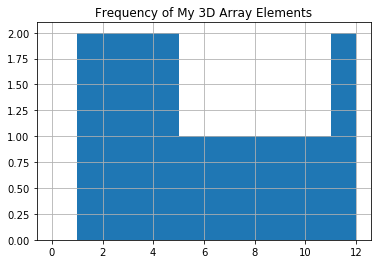

```python
# Construct the histogram with a flattened 3d array and a range of bins
# plt.hist() flattens data and the bins
plt.hist(my_3d_array.ravel(), bins = range(0,13))

# Add a title to the plot
plt.title('Frequency of My 3D Array Elements')
plt.grid(True)

# Show the plot
plt.show()
```

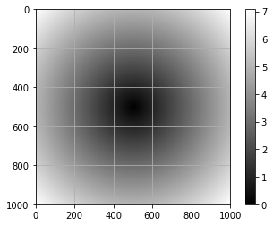

```python
# Create an array
points = np.arange(-5, 5, 0.01)

# Make a meshgrid
# need 2-D arrays of x and y coordinate values
# create a rectangular grid out of an array of x values and an array of y values
xs, ys = np.meshgrid(points, points)
z = np.sqrt(xs ** 2 + ys ** 2)

# Display the image on the axes
plt.imshow(z, cmap=plt.cm.gray)
plt.grid(True)

# Draw a color bar
plt.colorbar()

# Show the plot
plt.show()
```